# Single cell TCRseq

ImmunoGeneTeqs Inc.

2022-08-02

# 1 Single cell TCRseq結果のクオリティフィルタリング

各細胞で検出された総TCRリード数（左上）、およびその中で最多であったTCRリードの割合（左下）を示したヒストグラムを作成した。これから、十分な数のTCRリードが得られていない細胞、および他の細胞からのリーク等により十分な純度が得られていない細胞が少ないことを確認した。 続いて、上記2指標を用いて各細胞を散布図にプロットした（右）。各指標について一定の閾値を上回った細胞（散布図の右上の領域）のみを以降の解析に用いた。

## 1.1 TCRa

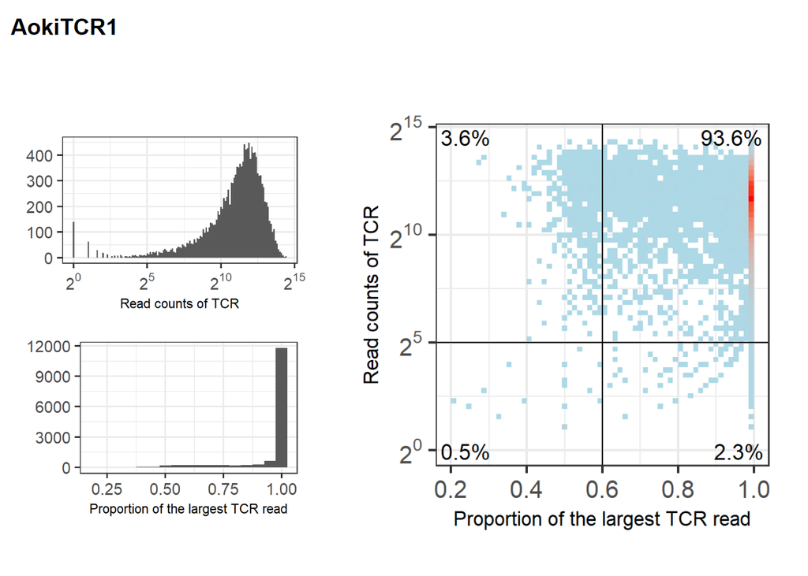

## 1.2 TCRb

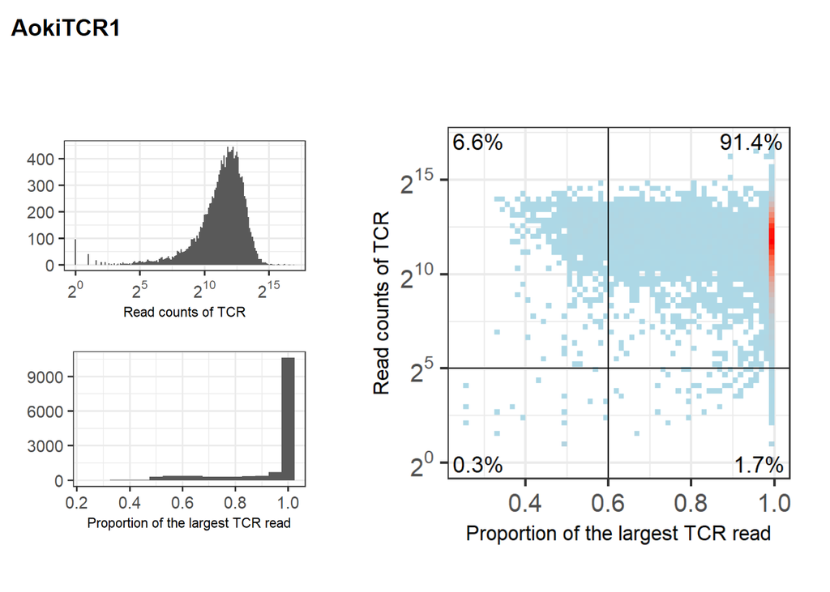

1.1 のヒストグラムと散布図は，“/Output.files/TRA/” に .tiffファイルとして，それぞれ保存した． また，1.2 のヒストグラムと散布図は，“/Output.files/TRB/” に .tiffファイルとして，それぞれ保存した．

# 2 Single cell TCRseqの性能評価

|  | batch | count | detect | prop |
| --- | --- | --- | --- | --- |
| 1 | mST05 | 6771 | 970 | 14.3% |
| 2 | mST06 | 6563 | 934 | 14.2% |
| 3 | mST07 | 566 | 123 | 21.7% |
| 4 | mST08 | 134 | 23 | 17.2% |
| 5 | mST09 | 66 | 11 | 16.7% |

# 3 代表的なT細胞クローンの性質

TCRaおよびTCRbのCDR3のヌクレオチド配列をもとに、T細胞クローンを同定し、各クローンの総細胞数 (cell_count) と頻度 (freq) を計算した。

続いて、SCT解析における細胞のクラスタリング結果を利用し、T細胞クローンごとにそれぞれのクラスターに属する細胞数を集計した (clusterX)。

加えて、代表的なクローンについては、クローンを構成するT細胞の遺伝子発現プロファイルを次元圧縮して示した (“Figure” 内の左図)。加えて、各クローンを構成するT細胞のうち、single cell RNAseqで同定されたクラスターに属する細胞の割合を円グラフで表示している (“Figure” 内の右図)。

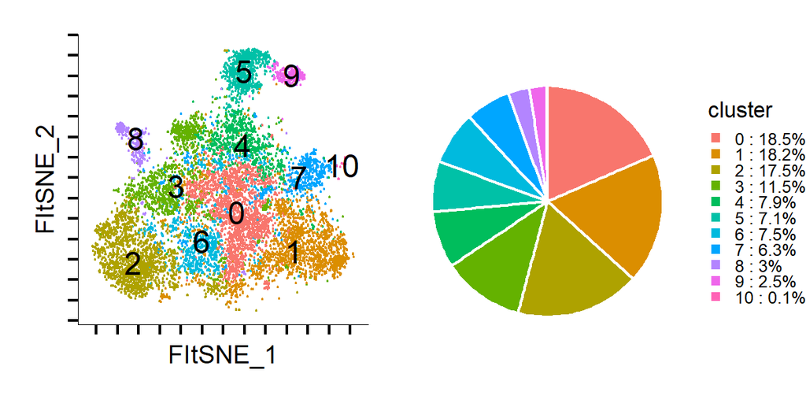

Scatter plot and Pie charts.

全細胞でのScatter plotとPie chartsの.pngファイルは，“All.clone.plot.png” として，“/Output.files/scTCR_analysis/”に保存した．

[output not shown]

[output cut: 1893 more lines]

各クローンごとのScatter plot, Pie chartsの.tiffファイルは，“/Output.files/scTCR_analysis”に保存した．

また，scTCRの結果を反映させたSeurat objectファイル (AokitargetBD_SeuratscTCRmerged.ABnt.rda)は，“/Output.files/”に保存した．

各Clusterで検出されたT細胞数, クローン数, およびレパトアのClonality (1-Pielou index) は下表のとおりである。

|  | cluster0 | cluster1 | cluster2 | cluster3 | cluster4 | cluster5 | cluster6 | cluster7 | cluster8 | cluster9 | cluster10 |
| --- | --- | --- | --- | --- | --- | --- | --- | --- | --- | --- | --- |
| Cell count | 2223 | 2189 | 2103 | 1382 | 954 | 856 | 903 | 761 | 356 | 300 | 12 |
| Clone count | 278 | 347 | 294 | 339 | 416 | 552 | 153 | 163 | 151 | 285 | 11 |
| Clonality | 0.303 | 0.294 | 0.277 | 0.186 | 0.114 | 0.153 | 0.254 | 0.236 | 0.122 | 0.013 | 0.012 |